# Exploratory Analysis Template

## Data Conversion Tools

Convert columns if necessary

### Convert Columns to Factors

Factors are used to work with categorical variables, variables that have a fixed and known set of possible values. They are useful for use in regression models because they act as dummy variables, and can also be displayed in a non-alphabetical order.

> Adjust number in filter to change unique count cutoff limit

```r
## Identify columns to be converted to factors
temp <- dataset[colnames(dataset[,sapply(dataset,is.character)])] %>% summarise_all(funs(n_distinct(.)))
factor_columns <- melt(as.data.frame(temp)) %>% filter(value <= 15) %>% select(variable) %>% .[["variable"]] %>% as.character()
## Convert columns to factors if less than 15 unique values
dataset[factor_columns] <- lapply(dataset[factor_columns], factor)
```

### Additional Data Conversion

> Change column names as needed

```r
## Integer conversion
#dataset$Survived <- as.integer(dataset$Survived)

## Date conversion
#dataset$Survived <- as.Date(dataset$Survived)

## Convert a column to character
#dataset$status <- as.character(dataset$status)

## Convert a column to factor
#dataset$Survived <- as.factor(dataset$Survived)

## Convert ALL categorical columns to factors
#dataset[categorical_columns] <- lapply(dataset[categorical_columns], factor)
```

# Missing data

## Examination

### NULLs

```r
#dplyr statement, take nulls and make them NA. ALSO add a flag column that designates that the row had null
dataset <- dataset %>% replace(.=="NULL", NA)
```

### NA’s

#### Missing Data Counts

> Replace column names with desired columns to be changed

```r
## Sum of missing values per column
colSums(is.na(dataset))
```

```
## Survived   Pclass     Name      Sex      Age    SibSp    Parch   Ticket
##        0        0        0        0      177        0        0        0
##     Fare    Cabin Embarked
##        0      687        2
```

```r
## View records containing missing data
#dataset[!complete.cases(dataset), ]
```

#### Visualize Missing Data Patterns

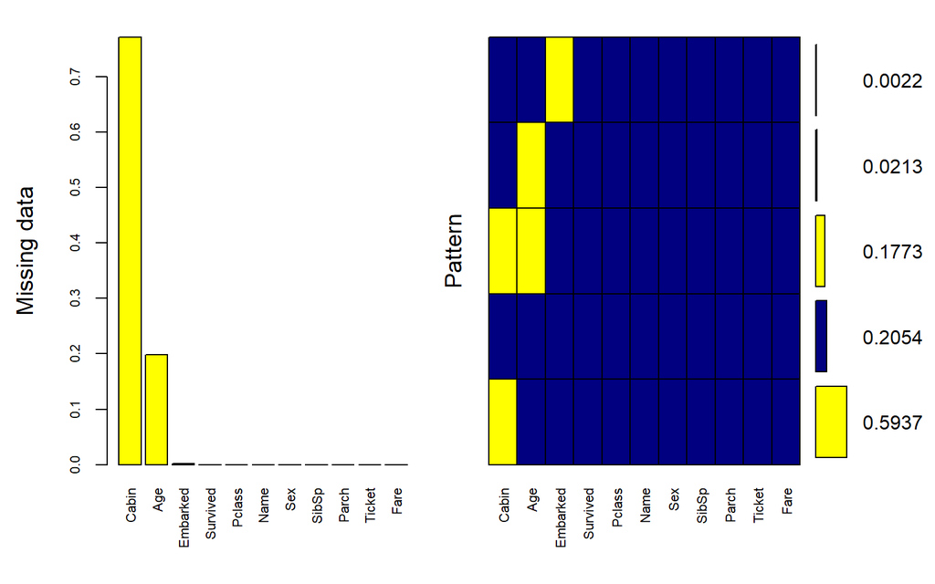

```
##
##  Variables sorted by number of missings:
##  Variable       Count
##     Cabin 0.771043771
##       Age 0.198653199
##  Embarked 0.002244669
##  Survived 0.000000000
##    Pclass 0.000000000
##      Name 0.000000000
##       Sex 0.000000000
##     SibSp 0.000000000
##     Parch 0.000000000
##    Ticket 0.000000000
##      Fare 0.000000000
```

```r
mice_plot <- aggr(dataset, col=c('navyblue','yellow'),
                    numbers=TRUE, sortVars=TRUE,
                    labels=names(dataset), cex.axis=.7,
                    gap=3, ylab=c("Missing data","Pattern"))
```

#### Percentage of Missing Values Per Feature

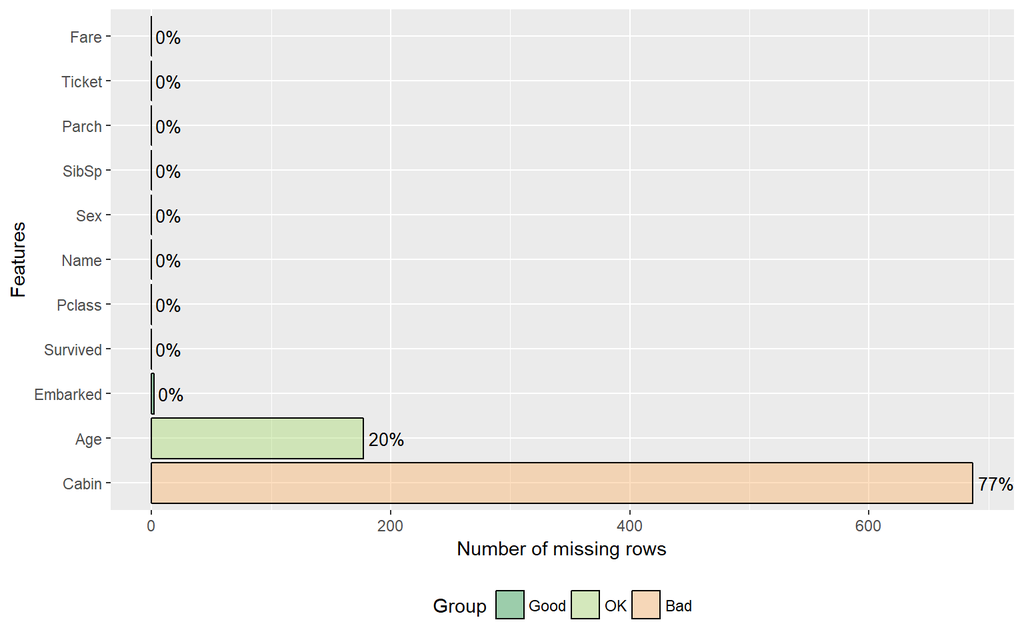

```r
plot_missing(dataset)
```

## Missing Data Handling Options

### Exclude

> Change column names to desired columns

```r
## Omit all incomplete (containing NA) records
dataset <- na.omit(dataset)

## Drop specific columns with missing data
#dataset <- dataset[ , !(names(dataset) %in% c("Column1", "Column2"))]
```

### Inpute Missing Data

#### Simple Recoding Methods

```r
## mean of column
#dataset$Age[is.na(dataset$Age)] <- mean(dataset$Age, na.rm = TRUE)
```

#### Impute With MICE

MICE assumes that the missing data are Missing at Random (MAR), which means that the probability that a value is missing depends only on observed value and can be predicted using them. It imputes data on a variable by variable basis by specifying an imputation model per variable.

For example: Suppose we have X1, X2..Xk variables. If X1 has missing values, then it will be regressed on other variables X2 to Xk. The missing values in X1 will be then replaced by predictive values obtained. Similarly, if X2 has missing values, then X1, X3 to Xk variables will be used in prediction model as independent variables. Later, missing values will be replaced with predicted values.

By default, linear regression is used to predict continuous missing values. Logistic regression is used for categorical missing values. Once this cycle is complete, multiple data sets are generated. These data sets differ only in imputed missing values. Generally, it’s considered to be a good practice to build models on these data sets separately and combining their results.

```r
## Inpute missing data
#imputed_Data <- mice(dataset, m=5, maxit = 50, method = 'pmm', seed = 500)

#summary(imputed_Data)

## Create density plot of inputed variables. You are looking to be sure the distributions are about equal. Blue represents actual observations.
#densityplot(imputed_Data)

## Add the inputed data back into the dataset to complete it
#dataset_mice <- complete(imputed_Data,1)
```

#### Impute With missForest

missForest is an implementation of random forest algorithm. It’s a non parametric imputation method applicable to various variable types.It builds a random forest model for each variable. Then it uses the model to predict missing values in the variable with the help of observed values.

Since bagging works well on categorical variable too, we don’t need to remove them here.

```r
## This probably needs a matrix

#library(missForest)

#imputed_Data <- missForest(dataset)
```

#### Impute With Hmisc

aregImpute() allows mean imputation using additive regression, bootstrapping, and predictive mean matching.

In bootstrapping, different bootstrap resamples are used for each of multiple imputations. Then, a flexible additive model (non parametric regression method) is fitted on samples taken with replacements from original data and missing values (acts as dependent variable) are predicted using non-missing values (independent variable).

Then, it uses predictive mean matching (default) to impute missing values. Predictive mean matching works well for continuous and categorical (binary & multi-level)

```r
## Testing tool for seeding missing data
#dataset <- prodNA(dataset, noNA = 0.1)

## Inpute missing data
#impute_arg <- aregImpute(~ Age + Fare + Sex, data = dataset, n.impute = 5)
```

# Categorical Data

## Examination

### Glimpse Data in Categorical Columns

```r
glimpse(dataset[,sapply(dataset,is.character)])
```

```
## Observations: 183
## Variables: 3
## $ Name   <chr> "Cumings, Mrs. John Bradley (Florence Briggs Thayer)", ...
## $ Ticket <chr> "PC 17599", "113803", "17463", "PP 9549", "113783", "24...
## $ Cabin  <chr> "C85", "C123", "E46", "G6", "C103", "D56", "A6", "C23 C...
```

```r
glimpse(dataset[,sapply(dataset,is.factor)])
```

```
## Observations: 183
## Variables: 2
## $ Sex      <fctr> female, female, male, female, female, male, male, ma...
## $ Embarked <fctr> C, S, S, S, S, S, S, S, C, C, S, S, S, S, S, C, C, S...
```

### Create Frequency Distributions for Categorical Column

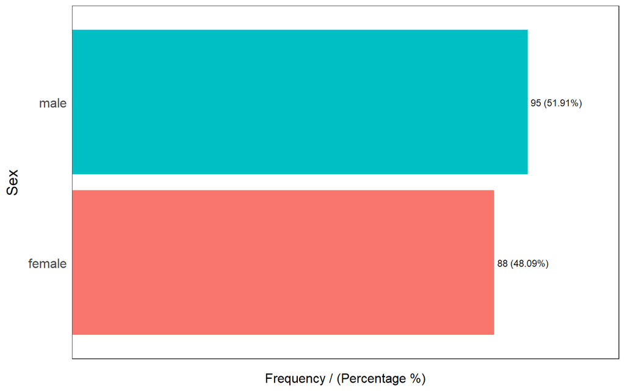

```
##      Sex frequency percentage cumulative_perc
## 1   male        95      51.91           51.91
## 2 female        88      48.09          100.00
```

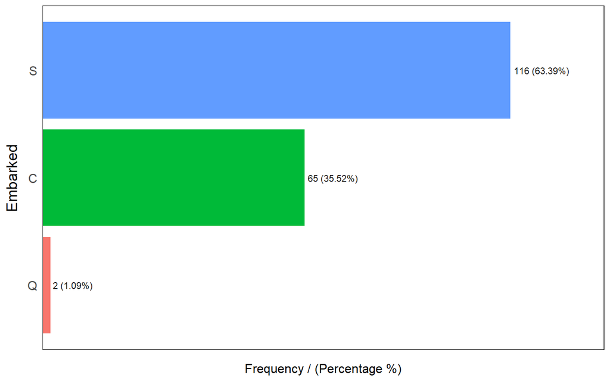

```
##   Embarked frequency percentage cumulative_perc
## 1        S       116      63.39           63.39
## 2        C        65      35.52           98.91
## 3        Q         2       1.09          100.00
```

```
## [1] "Variables processed: Sex, Embarked"
```

```r
#Not just factors, apply rules
freq(dataset[,sapply(dataset,is.factor)])
```

### Count Levels of Factor Variables

> Change column name to column of interest

```r
#Show counts of levels
lengths(lapply(dataset[categorical_columns], levels))
```

```
##     Name      Sex   Ticket    Cabin Embarked
##        0        2        0        0        3
```

## Factor Relevel

Examine and re-order factors in the dataset

> Change column name to column of interest

```r
## Show all levels of a factor
#levels(dataset$Embarked)

## Manually order factors
#dataset$Embarked <- factor(dataset$Embarked, levels = c("S", "Q", "C"))

## Make a specific factor first
#dataset$Embarked <- relevel(dataset$Embarked, "Q")

## Reverse the order of the factor
#dataset$Embarked <- factor(dataset$Embarked, levels=rev(levels(dataset$Embarked)))
```

# Numerical Data

## Histograms

Create histograms of each variables distribution

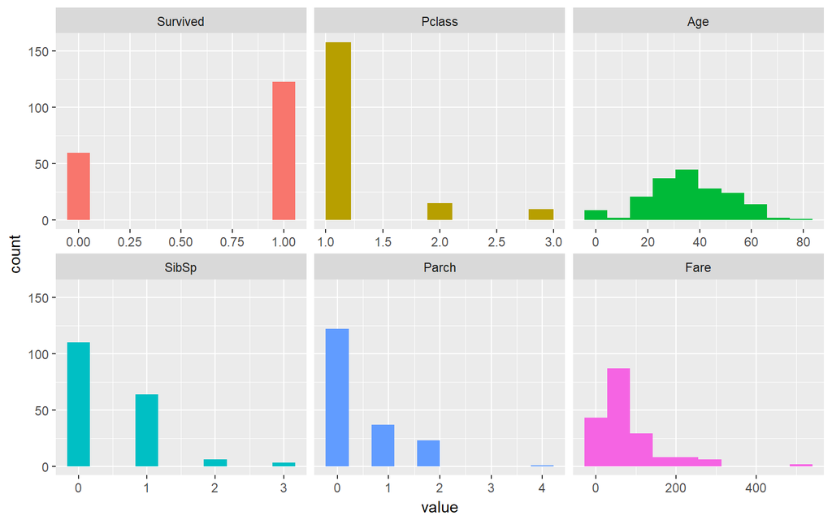

```r
plot_num(dataset)
```

## Profile Information

Profile information for each numeric variable

```r
profiling_num(dataset)
```

```
##   variable  mean std_dev variation_coef p_01 p_05 p_25 p_50 p_75  p_95
## 1 Survived  0.67    0.47           0.70  0.0  0.0    0    1    1   1.0
## 2   Pclass  1.19    0.52           0.43  1.0  1.0    1    1    1   2.9
## 3      Age 35.67   15.64           0.44  1.8  6.5   24   36   48  60.9
## 4    SibSp  0.46    0.64           1.39  0.0  0.0    0    0    1   1.0
## 5    Parch  0.48    0.75           1.59  0.0  0.0    0    0    1   2.0
## 6     Fare 78.68   76.35           0.97  4.1 10.5   30   57   90 245.5
##   p_99 skewness kurtosis iqr      range_98     range_80
## 1    1  -0.7334      1.5   1        [0, 1]       [0, 1]
## 2    3   2.6594      8.9   0        [1, 3]       [1, 2]
## 3   70   0.0096      2.7  24 [1.82, 70.18]   [17.2, 56]
## 4    3   1.4312      5.4   1        [0, 3]       [0, 1]
## 5    2   1.5068      4.9   1        [0, 2]       [0, 2]
## 6  308   2.6936     13.4  60 [4.1, 307.88] [13, 153.46]
```

| Item | Definition |
| --- | --- |
| variation_coef | A measure of relative variability. It is the ratio of the standard deviation to the mean (average). For example, the expression ‘The standard deviation is 15% of the mean’ |
| skewness | Skewness is a measure of symmetry, or more precisely, the lack of symmetry. A distribution, or data set, is symmetric if it looks the same to the left and right of the center point. |
| kurtosis | Kurtosis is a measure of whether the data are heavy-tailed or light-tailed relative to a normal distribution. That is, data sets with high kurtosis tend to have heavy tails, or outliers. Data sets wit… |

# Collinearity

### Correlation Matrix

Compute a correlation matrix using all numeric columns

```r
cor(select_if(dataset,is.numeric), use = "complete.obs")
```

```
##          Survived Pclass    Age SibSp  Parch   Fare
## Survived    1.000 -0.035 -0.254  0.11  0.024  0.134
## Pclass     -0.035  1.000 -0.307 -0.10  0.047 -0.315
## Age        -0.254 -0.307  1.000 -0.16 -0.271 -0.092
## SibSp       0.106 -0.104 -0.156  1.00  0.255  0.286
## Parch       0.024  0.047 -0.271  0.26  1.000  0.390
## Fare        0.134 -0.315 -0.092  0.29  0.390  1.000
```

### Correlation Matrix Visualized

The correlation coefficents can be visualized

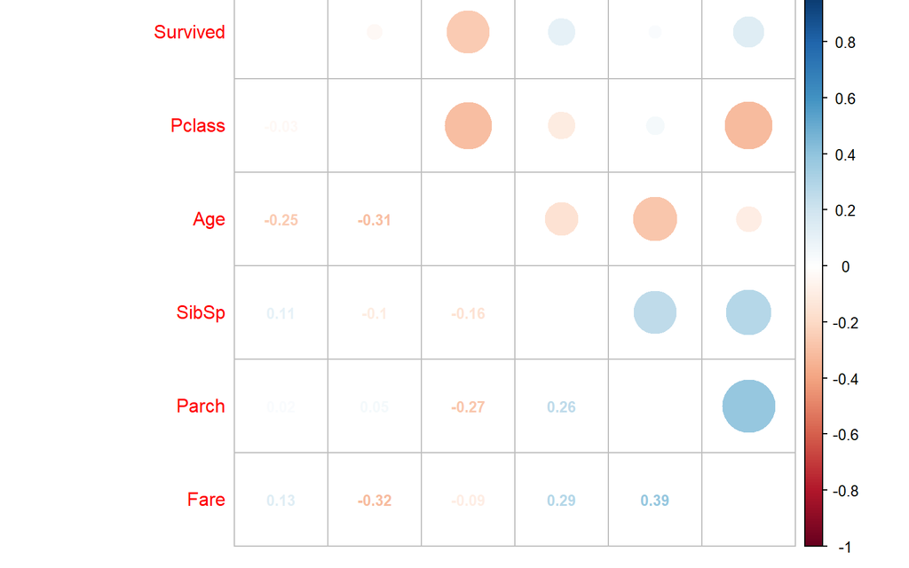

```r
myCOR <- cor(select_if(dataset,is.numeric), use = "complete.obs")
corrplot.mixed(myCOR, number.cex = .8, tl.pos = "lt")
```

#### Individual Coefficient Examination

Examine any individual coefficients

> Change column names to columns of interest

```r
#cor.test(dataset$column1, dataset$column2)
```

Chart additional correlation information

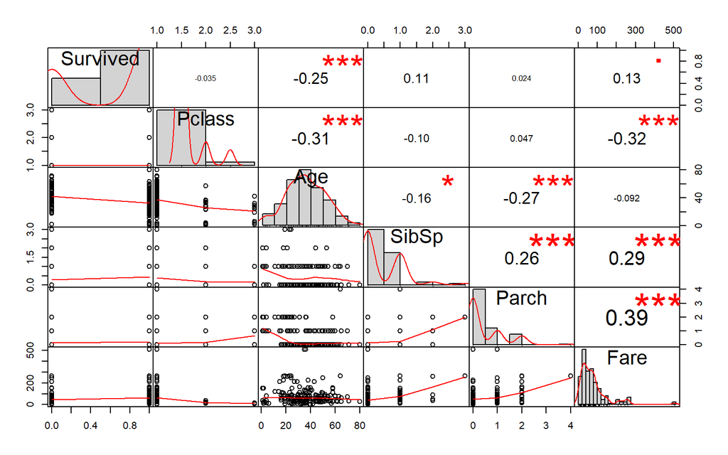

```r
chart.Correlation(select_if(dataset,is.numeric), histogram = TRUE, pch = 19)
```

### Alternate Visualizations

Alternative correlation plot

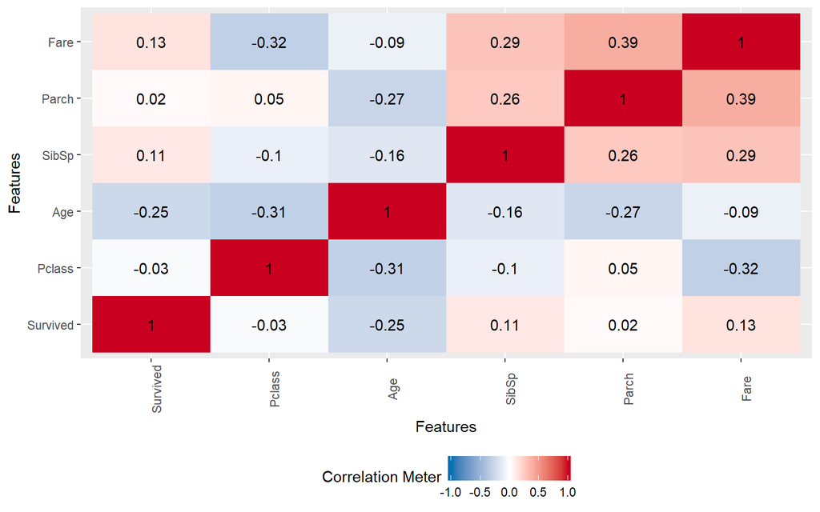

```r
#Alternative method - DataExplorer
plot_correlation(dataset, type = 'continuous','Review.Date')
```

Alternative correlation plot- includes categorical variables

```
## 3 features with more than 20 categories ignored!
## Name: 183 categories
## Ticket: 127 categories
## Cabin: 133 categories
```

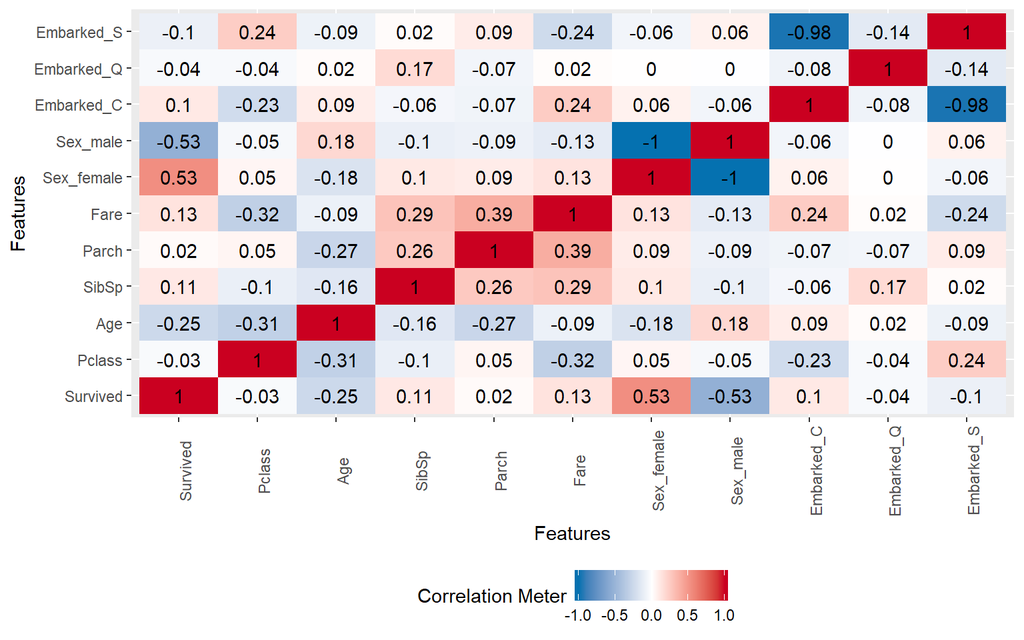

```r
plot_correlation(dataset, use = "pairwise.complete.obs")
```

Additional Option which includes matrix of p-values

```r
#rcorr(as.matrix(select_if(dataset,is.numeric)), type="pearson")
```

### Information Theory

Additional correlation analysis, based on several information theory metrics between all variables in a data frame and a target variable.

> Change the variable to target variable

```r
#var_rank_info(dataset, "Survived")
```

# Data Distribution

## Distribution Plots

Distribution plot between input and target variable

Add check if there’s a variable that works

```r
## Plot all numeric columns
try(cross_plot(data=dataset, input=colnames(select_if(dataset,is.numeric)), target= myLabel))

## Call specific columns only
#cross_plot(data=dataset, input=c("budget", "runtime"), target= target)
```

[output not shown]

## Box Plots

```r
## Plot all numeric columns
try(plotar(data=dataset, input = colnames(select_if(dataset,is.numeric)), target= myLabel, plot_type="boxplot"))

## Call specific columns only
#plotar(data=dataset, input = c("Age", "Fare"), target= target, plot_type="boxplot")
```

[output not shown]

### Quantitative Analysis for Binary Outcome

> Input variable must be categorical. Target variable must be binary.

```r
#df_ca = categ_analysis(data = dataset, input = "Sex", target = myLabel)

#head(df_ca)
```

# Outlier Detection

## Plot Columns to Identify Outliers

> Change the declared y-value to the column of interest

```r
#for (i in 1:length(numeric_columns)){
#print(numeric_columns[i])

#tempplot <- ggplot(dataset, aes(x = "", y = numeric_columns[i])) + geom_boxplot(outlier.color="red", outlier.shape=8, outlier.size=4) + #scale_y_continuous()
#}
```

> Below, change the variable cutOff to meet you needs. cutOff determines the number of unique values in each numeric column needed to produce a boxplot.

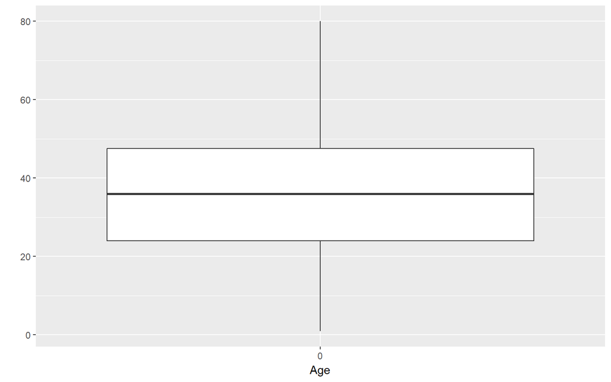

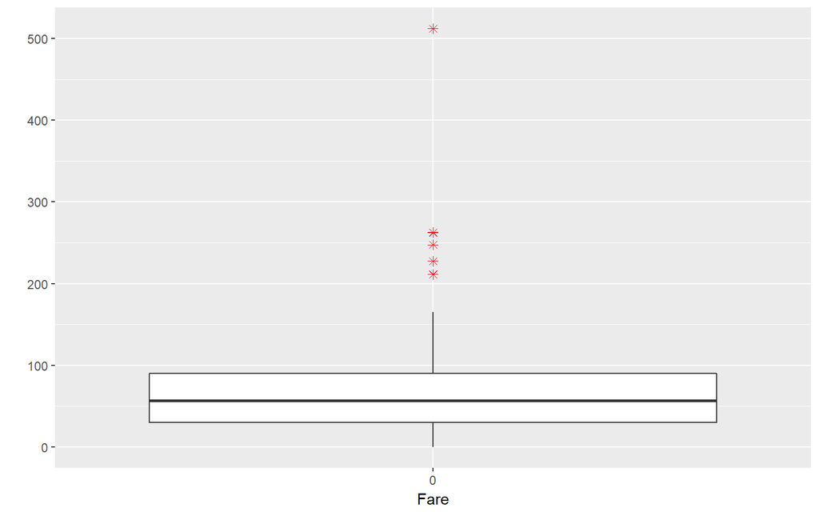

```r
cutOff = 10 #Number of unique values required to output a boxplot
tmpDF <- dataset[, sapply(dataset, is.numeric)] #get only numeric columns
tmpDF <- na.omit(tmpDF) #just a check to avoid ggplot messages

#keep cols that meet cutOff requirement
tmpDF <- tmpDF[, sapply(tmpDF, function(col) length(unique(col))) >= cutOff]
tmpDF <- data.frame(tmpDF)

#https://stackoverflow.com/questions/15027659/how-do-you-draw-a-boxplot-without-specifying-x-axis
plot_data = function (data, column)
    ggplot(data = data, aes_string(x = factor(0), y = column)) +
    geom_boxplot(outlier.color="red", outlier.shape=8, outlier.size=2) + xlab(column) + ylab("")

myplots <- lapply(colnames(tmpDF), plot_data, data = tmpDF)
myplots
```

```r
rm(cutOff, tmpDF, myplots)
```

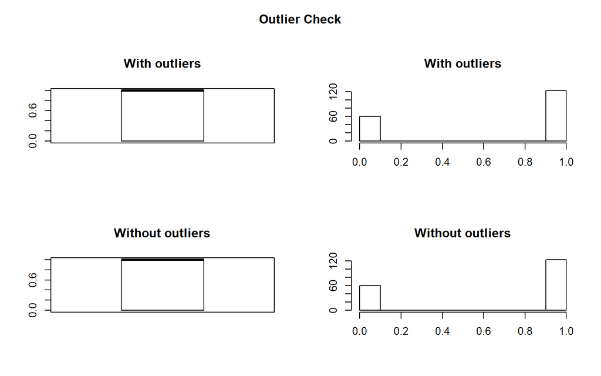

```
## Outliers identified: 0 nPropotion (%) of outliers: 0 nMean of the outliers: NaN nMean without removing outliers: 0.67 nMean if we remove outliers: 0.67 n
```

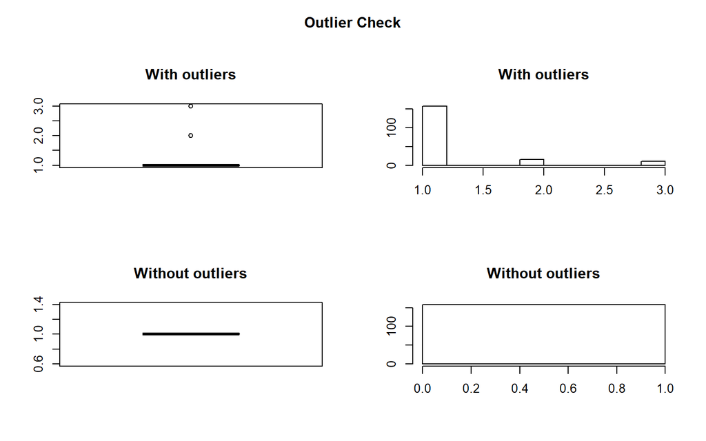

```
## Outliers identified: 25 nPropotion (%) of outliers: 16 nMean of the outliers: 2.4 nMean without removing outliers: 1.2 nMean if we remove outliers: 1 n
```

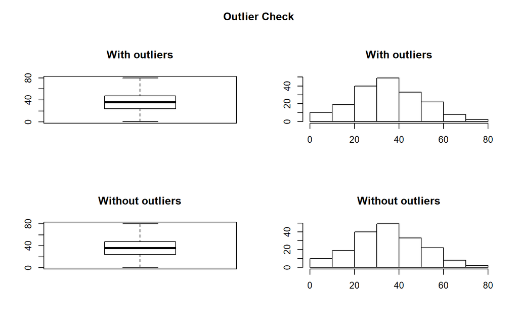

```
## Outliers identified: 0 nPropotion (%) of outliers: 0 nMean of the outliers: NaN nMean without removing outliers: 36 nMean if we remove outliers: 36 n
```

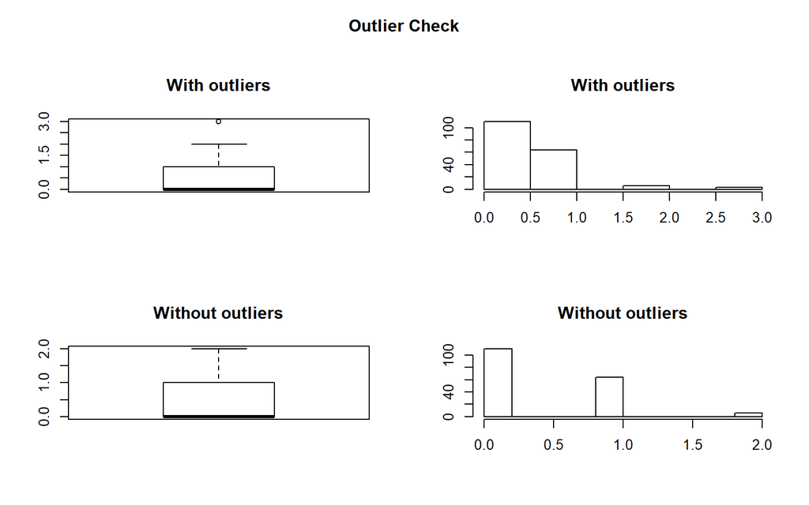

```
## Outliers identified: 3 nPropotion (%) of outliers: 1.7 nMean of the outliers: 3 nMean without removing outliers: 0.46 nMean if we remove outliers: 0.42 n
```

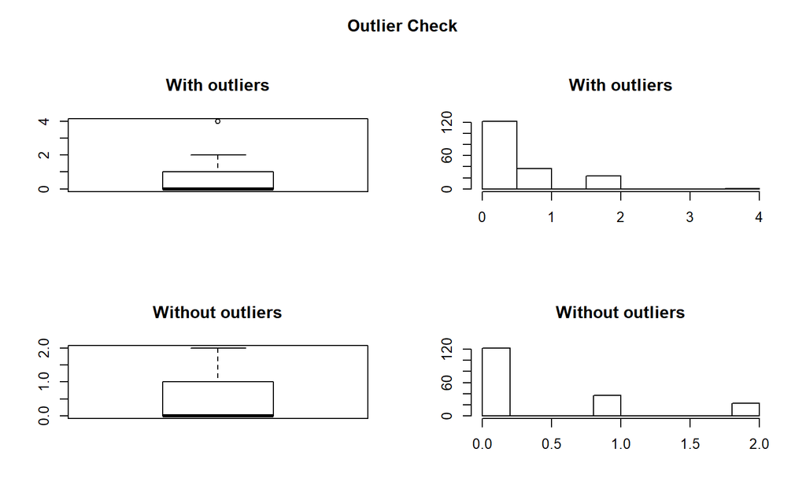

```
## Outliers identified: 1 nPropotion (%) of outliers: 0.5 nMean of the outliers: 4 nMean without removing outliers: 0.48 nMean if we remove outliers: 0.46 n
```

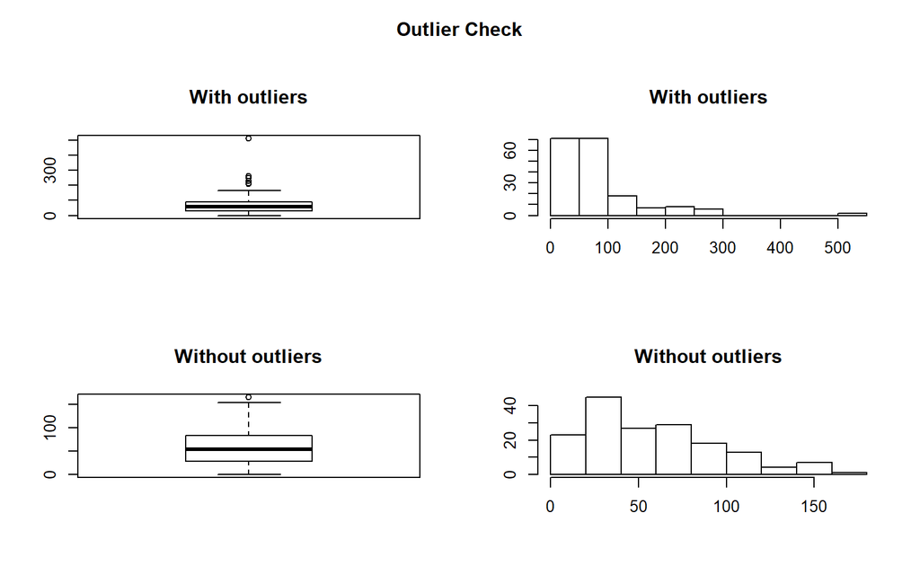

```
## Outliers identified: 16 nPropotion (%) of outliers: 9.6 nMean of the outliers: 275 nMean without removing outliers: 79 nMean if we remove outliers: 60 n
```

```r
outlierKD <- function(dt, var) {
     var_name <- eval(substitute(var),eval(dt))
     na1 <- sum(is.na(var_name))
     m1 <- mean(var_name, na.rm = T)
     par(mfrow=c(2, 2), oma=c(0,0,3,0))
     boxplot(var_name, main="With outliers")
     hist(var_name, main="With outliers", xlab=NA, ylab=NA)
     outlier <- boxplot.stats(var_name)$out
     mo <- mean(outlier)

     var_name <- ifelse(var_name %in% outlier, NA, var_name)
     boxplot(var_name, main="Without outliers")
     hist(var_name, main="Without outliers", xlab=NA, ylab=NA)

     title("Outlier Check", outer=TRUE)

     na2 <- sum(is.na(var_name))
     cat("Outliers identified:", na2 - na1, "n")
     cat("Propotion (%) of outliers:", round((na2 - na1) / sum(!is.na(var_name))*100, 1), "n")
     cat("Mean of the outliers:", round(mo, 2), "n")
     m2 <- mean(var_name, na.rm = T)
     cat("Mean without removing outliers:", round(m1, 2), "n")
     cat("Mean if we remove outliers:", round(m2, 2), "n")
     # response <- readline(prompt="Do you want to remove outliers and to replace with NA? [yes/no]: ")
     # if(response == "y" | response == "yes"){
     #      dt[as.character(substitute(var))] <- invisible(var_name)
     #      assign(as.character(as.list(match.call())$dt), dt, envir = .GlobalEnv)
     #      cat("Outliers successfully removed", "n")
     #      return(invisible(dt))
     # } else{
     #      cat("Nothing changed", "n")
     #      return(invisible(var_name))
     # }
}

for (i in 1:length(colnames(select_if(dataset,is.numeric)))){
outlierKD(dataset, get(paste(colnames(select_if(dataset,is.numeric)[i]))))
}
```

Examine the top 25 rows of a column containing outliers

> Change the column name to the specified column

```r
#tmpRev <- arrange(dataset, desc(Age)) %>% select(Age)
#tmpRev <- as.data.frame(head(tmpRev$Age, 25))
#names(tmpRev) <- "Age"
#tmpRev
```

## Outlier Handling Options

### Threshold Based

#### Set Thresholds for Outlier Detection.

The Tukey method formula: The bottom threshold is: Q1 - 3IQR. All below are considered as outliers. The top threshold is: Q1 + 3(IQR). All above are considered as outliers.

> Change columns to columns of interest

```r
## Tukey method outlier thresholds
#tukey_outlier(dataset$Fare)

## Hampel method outlier thresholds
#hampel_outlier(dataset$Fare)
```

#### Set Outliers Based on Thresholds

> Change column names if using specific columns

```r
## Set all values above the outlier threshold to the threshold value for all columns
#prep_outliers(data = dataset, input = colnames(select_if(dataset,is.numeric)), method = "hampel", type='stop')

## Set all values above the outlier threshold to the threshold value for Specified columns
#prep_outliers(data = dataset, input = c('Fare','Age'), method = "hampel", type='stop')
```

# Duplicates

## Examine Duplicates

### Count Number of Duplicated Rows

```r
## Show count of duplicate rows
nrow(dataset) - nrow(unique(dataset))
```

```
## [1] 0
```

### Review Duplicate Rows

```r
## Show all duplicated rows
head(dataset[duplicated(dataset), ])
```

| Survived | Pclass | Name | Sex | Age | SibSp | Parch | Ticket | Fare | Cabin | Embarked |
| --- | --- | --- | --- | --- | --- | --- | --- | --- | --- | --- |

## Remove Duplicates

```r
## Remove duplicate rows
#dataset <- dataset[!duplicated(df), ]
```

# Additional Testing Tools

```r
data(dataset, package = "reshape")
```

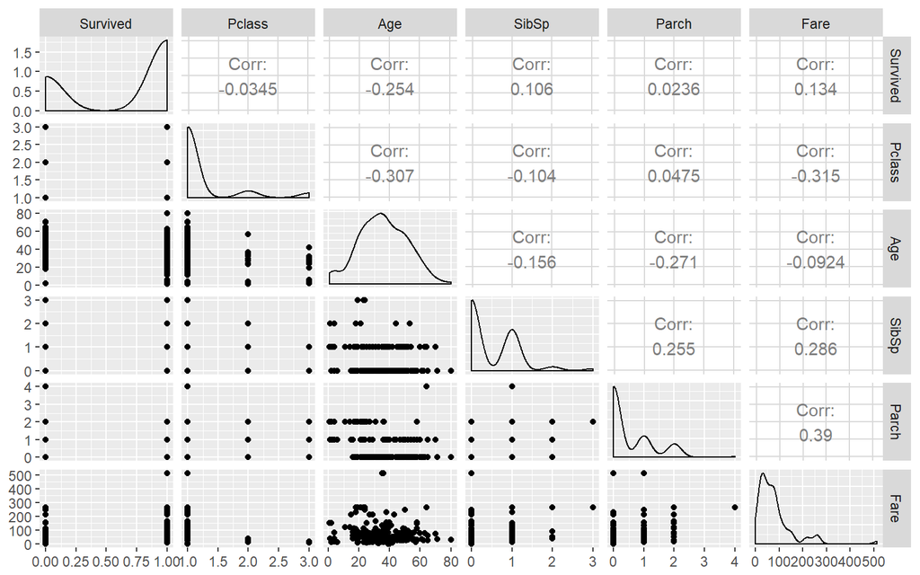

```r
pm <- ggpairs(select_if(dataset,is.numeric))
#pm <- ggpairs(dataset[numeric_columns], columns = c("total_bill", "time", "tip"))
pm
```

# Pre Processing

# Useful Code

## Data Munging Tools

```r
## Apply filters based on known business rules
#data <- filter(dataset, dataset$Number == 0, dataset$Category %in% c("Active", "Complete"))

## Drop unusused columns
#data <- dataset[ , !(names(dataset) %in% c("TaskBaselineFinishDate", "TaskBaselineStartDate"))]
```

## Data Splitting and Grouping Tools

```r
## Filter dataset, group by column and create new aggregate column
#constructionstart <- builddata %>%
#  filter(L2Milestone == "Construction Start" | T1Milestone == "Construction Start") %>%
#  group_by(ProjectID) %>%
#  summarise(ConstructionStartDate = min(TaskStartDate))
```